# Analisis de Salud Mental Durante la Pandemia de COVID-19

Juan Pablo Vargas

05/12/22

### Universidad Alberto Hurtado

### Curso Introducción al Programa R

#### Profesora: Valentina Andrade

#### Ayudante: Dafne Vargas

## 1. Abstract

Durante los últimos tres años el mundo entero ha vivido la conmoción de la pandemia de la COVID-19, y especialmente en Chile el impacto no ha sido menor. Gran parte de los problemas de la pandemia fueron producto de esta como el confinamiento y la recesión. En específico, y a raíz del confinamiento, la salud mental de las personas ha sufrido diferentes cambios debido al poco desarrollo social existente durante las cuarentenas vividas en gran medida durante el 2020 en nuestro país. Es por esto que es de gran importante investigar los efectos de la pandemia en la salud mental de los chilenos para que prontamente se puedan abordar políticas publicas en favor del bienestar de la sociedad.

Palabras Claves: Salud Mental, COVID-19, Chile.

## 2. Introduccion

Las cuarentenas aplicadas durante el gobierno de Sebastián Piñera impusieron restricción a la sociedad nunca antes presentadas en el país, o no de la magnitud que se vivió durante los meses en que se aplicó. Los efectos colaterales afectaron varias aristas de la población de Chile; en temas económicos se produjeron grandes problemas en las pérdidas de empleos, en la baja de sueldos, el alza del costo de la vida, entre otras. En una arista de mayor importancia, la COVID-19 afecto fuertemente la salud física de las personas debido a las grandes tasas de contagios que se produjeron durante todo el transcurso de la pandemia, pero, algo que no ha tomado la relevancia que se merece, la COVID-19 y el confinamiento produjeron efectos colaterales graves en la salud mental de las personas, es así que durante estos años se han realizado diversos estudios y encuestas para saber el real efecto de la enfermedad en temas como la salud mental. Es así como “Termómetro Social” ha podido establecer diferentes encuestas con estos fines, y en esta investigación se ha utilizado la última realizada en este centro de estudios, realizada en octubre de 2020. En uno de los módulos establecidos aquí, es orientado específicamente hacia la salud mental, con once preguntas sobre la temática se busca saber el impacto de la COVID-19 en la salud mental, por ejemplo, en el consumo de medicamentos como antidepresivos, si cree necesario asistir a sesiones de terapia, el animo que poseen durante la pandemia, entre otras.

## 3. Analisis de Datos

## Carga de Paquetes

```r
pacman::p_load(tidyverse,
               haven,
               forcats,
               car,
               sjmisc,
               sjPlot,
               survey,
               srvyr,
               kableExtra)
```

## Carga de Datos

```r
load("../output/data/TS4_Proc.RData")
```

## Creacion Objeto Encuesta

```r
objeto_encuesta<- TS4_Proc %>%
  as_survey_design(ids = folio,
                   strata = region,
                   weights = factor_TS4)
```

## Creacion de Graficos

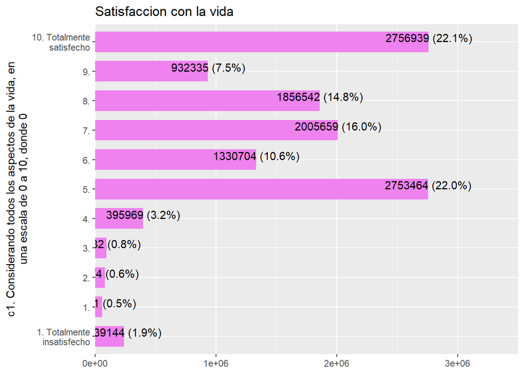

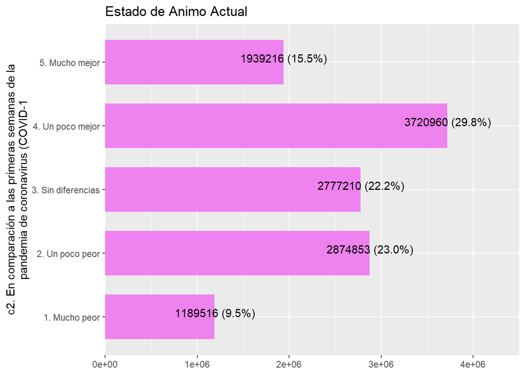

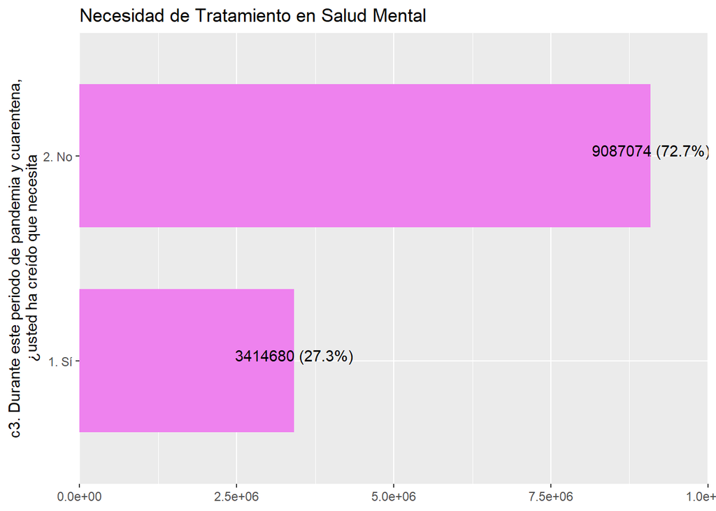

## Creacion de Tablas

Consumo de Medicamentos

| c6 | porcentaje | porcentaje_low | porcentaje_upp |
| --- | --- | --- | --- |
| Ha Aumentado | 21.673290 | 14.643867 | 28.702712 |
| Ha Disminuido | 5.750796 | 1.673658 | 9.827934 |
| No Consume | 43.715683 | 36.358150 | 51.073216 |
| Se Ha Mantenido | 28.860232 | 22.599645 | 35.120819 |

Frecuencia de Conversacion de Problemas

| c10 | porcentaje | porcentaje_low | porcentaje_upp |
| --- | --- | --- | --- |
| Algunas Veces | 26.390170 | 19.161751 | 33.61859 |
| Muchas Veces | 15.824904 | 10.068172 | 21.58164 |
| Nunca | 5.627336 | 2.875143 | 8.37953 |
| Pocas Veces | 18.948808 | 12.947198 | 24.95042 |
| Siempre | 33.208782 | 26.636754 | 39.78081 |

Padres han recibido Diagnostico de Salud Mental

| c11 | porcentaje | porcentaje_low | porcentaje_upp |
| --- | --- | --- | --- |
| No | 81.47137 | 75.26874 | 87.67399 |
| Si | 18.52863 | 12.32601 | 24.73126 |

## 4. Analisis Descriptivo

El análisis final que se puede hacer luego de haber revisado la base de datos y seleccionar las variables relacionadas con la salud mental en pandemia, es, en primer lugar, que gran parte de la población chilena se ha encontrado satisfecha con la vida en grados altamente satisfechos, como se puede apreciar en el grafico 1, más del 90% de la sociedad se encuentra entre medianamente satisfecha y totalmente satisfecha con la vida, dando a entender que la pandemia en promedio no ha afectado de gran forma la satisfacción de la vida, algunas de las razones puede ser que compartir el hogar con sus familias les ayuda a resistir de mejor manera la pandemia. En términos de estados de ánimos, la población chilena presenta resultados opuestos, en promedio un 45% de la población ha respondido que su animo se encuentra mejor o mucho mejor, y en cambio, en promedio un 33% se ha presentado un poco peor o mucho peor, dando a entender que el con el pasar de la pandemia las expectativas de un mejoramiento de las condiciones sigue dispar. En el tercer gráfico, podemos notar que las personas en una amplia mayoría, en promedio han creído no necesitar de atención psicológica, por lo que se puede correlacionar con los resultados de la segunda tabla, ya que, en esta, en promedio, el 75% de los/as chilenos/as conversan de sus problemas con amigos o su familia, siempre, algunas y muchas veces, por lo que, se da a entender que la terapia psicológica no es tan necesaria al poseer personas de soporte en sus círculos cercanos. Con relación a la primera tabla el consumo de medicamento por parte de la población, por ejemplo, antidepresivos, en promedio, el 50% de los/as chilenos/as ha mantenido o ha aumentado su consumo, siendo un efecto preocupante de la pandemia, esto porque da señales de que las personas han recurrido a la auto medicación para solventar problemas físicos y mentales producidos por la COVID-19. En ultimo lugar, en relación a la tercera tabla, en promedio, una gran mayoría de la población ha podido manifestar que ninguno de sus padres ha recibido un diagnostico de salud mental, tales como depresión, bipolaridad, TDAH, TDA, entre otras, por lo que se puede inferir que la gran mayoría de personas no ha presentado problemas en el ámbito mental producto de los lazos paternales.

## 5. Conclusion

Como conclusión, podemos destacar que de todas maneras la pandemia ha afectado en diferentes grados la salud mental de las personas, las políticas públicas que se deberían efectuar deben ser en especifico para controlar la auto medicación de las personas al no realizar una búsqueda oportuna de atención médica. Por otro lado, aunque la mayoría de la población no presenta necesidad de buscar terapia psicológica debido al apoyo de redes de amigos y familiares, si es importante informar sobre la importancia de esta para ellos mismo o para alguno de sus cercanos. Este estudio se llevó a cabo principalmente en la población adulta del país, entre 18 y 64 años, por lo que los efectos pueden variar dependiendo del sexo y la edad de las personas, por lo que es importante prestarles atención a estos factores para una solución mediante políticas publicas enfocadas a los grupos de mayor riesgo.